# Short software tutorial on `nonprobsvy` package – replicating results from the Yang et al. (2020)

## 1.3 Single run

### 1.3.1 Generate samples

Now, we provide a single run. First, we generate probability sample and calibrate to known population totals from `X_totals`.

```r
sample_A_svy <- svydesign(ids = ~ 1, probs = ~ pi_A, pps = "brewer", data = pop_data[pop_data$flag_A == 1, ])

sample_A_svy_cal <- calibrate(sample_A_svy,
                              formula = X_formula,
                              population = X_totals,
                              calfun = cal.raking)
```

Next, we generate two samples based on `flag_B1` and `flag_B2`.

```r
sample_B1 <- pop_data[pop_data$flag_B1 == 1, ]
sample_B2 <- pop_data[pop_data$flag_B2 == 1, ]
```

### 1.3.2 Estimators under PSM I

Naive estimator.

```r
est_naive <- aggregate(cbind(Y_11,Y_12,Y_21,Y_22) ~ 1, sample_B1, mean)
```

IPW with variable selection using SCAD penalty (note that this IPW is IPW with calibration constraints on selected variables).

```r
est_ipw <- nonprob(selection = X_formula,
                   target = ~ Y_11 + Y_12 + Y_21 + Y_22,
                   data = sample_B1,
                   svydesign = sample_A_svy_cal,
                   control_inference = controlInf(vars_selection = TRUE))
```

Mass imputation with SCAD penalty.

```r
est_mi_y11 <- nonprob(outcome = as.formula(paste("Y_11 ~ ", as.character(X_formula)[2])),
                      data = sample_B1,
                      svydesign = sample_A_svy_cal,
                      control_inference = controlInf(vars_selection = TRUE),
                      family_outcome = "gaussian")
est_mi_y12 <- nonprob(outcome = as.formula(paste("Y_12 ~ ", as.character(X_formula)[2])),
                      data = sample_B1,
                      svydesign = sample_A_svy_cal,
                      control_inference = controlInf(vars_selection = TRUE),
                      family_outcome = "gaussian")
est_mi_y21 <- nonprob(outcome = as.formula(paste("Y_21 ~ ", as.character(X_formula)[2])),
                      data = sample_B1,
                      svydesign = sample_A_svy_cal,
                      control_inference = controlInf(vars_selection = TRUE),
                      family_outcome = "binomial")
est_mi_y22 <- nonprob(outcome = as.formula(paste("Y_22 ~ ", as.character(X_formula)[2])),
                      data = sample_B1,
                      svydesign = sample_A_svy_cal,
                      control_inference = controlInf(vars_selection = TRUE),
                      family_outcome = "binomial")
```

DR with variables based on mass imputation with SCAD penalty.

```r
est_dr_pred_y11 <- nonprob(outcome = as.formula(paste("Y_11 ~ ",
                                                      paste(names(est_mi_y11$parameters[,1])[-1],
                                                            collapse = "+"))),
                           selection = as.formula(paste(" ~ ",
                                                      paste(names(est_mi_y11$parameters[,1])[-1],
                                                            collapse = "+"))),
                           data = sample_B1,
                           svydesign = sample_A_svy,
                           family_outcome = "gaussian")
est_dr_pred_y12 <- nonprob(outcome = as.formula(paste("Y_12 ~ ",
                                                      paste(names(est_mi_y12$parameters[,1])[-1],
                                                            collapse = "+"))),
                           selection = as.formula(paste(" ~ ",
                                                      paste(names(est_mi_y12$parameters[,1])[-1],
                                                            collapse = "+"))),
                           data = sample_B1,
                           svydesign = sample_A_svy,
                           family_outcome = "gaussian")
est_dr_pred_y21 <- nonprob(outcome = as.formula(paste("Y_21 ~ ",
                                                      paste(names(est_mi_y21$parameters[,1])[-1],
                                                            collapse = "+"))),
                           selection = as.formula(paste(" ~ ",
                                                      paste(names(est_mi_y21$parameters[,1])[-1],
                                                            collapse = "+"))),
                           data = sample_B1,
                           svydesign = sample_A_svy,
                           family_outcome = "binomial")
est_dr_pred_y22 <- nonprob(outcome = as.formula(paste("Y_22 ~ ",
                                                      paste(names(est_mi_y22$parameters[,1])[-1],
                                                            collapse = "+"))),
                           selection = as.formula(paste(" ~ ",
                                                      paste(names(est_mi_y22$parameters[,1])[-1],
                                                            collapse = "+"))),
                           data = sample_B1,
                           svydesign = sample_A_svy,
                           family_outcome = "binomial")
```

DR without bias minimization but with union of variables.

```r
est_dr_y11 <- nonprob(outcome = as.formula(paste("Y_11 ~ ", as.character(X_formula)[2])),
                     selection = X_formula,
                     data = sample_B1,
                     svydesign = sample_A_svy,
                     control_inference = controlInf(vars_selection = TRUE),
                     family_outcome = "gaussian")
est_dr_y12 <- nonprob(outcome = as.formula(paste("Y_12 ~ ", as.character(X_formula)[2])),
                     selection = X_formula,
                     data = sample_B1,
                     svydesign = sample_A_svy,
                     control_inference = controlInf(vars_selection = TRUE),
                     family_outcome = "gaussian")
est_dr_y21 <- nonprob(outcome = as.formula(paste("Y_21 ~ ", as.character(X_formula)[2])),
                     selection = X_formula,
                     data = sample_B1,
                     svydesign = sample_A_svy,
                     control_inference = controlInf(vars_selection = TRUE),
                     family_outcome = "binomial")
est_dr_y22 <- nonprob(outcome = as.formula(paste("Y_22 ~ ", as.character(X_formula)[2])),
                     selection = X_formula,
                     data = sample_B1,
                     svydesign = sample_A_svy,
                     control_inference = controlInf(vars_selection = TRUE),
                     family_outcome = "binomial")
```

DR with bias minimization with union of variables after selection of variables with SCAD.

```r
est_dr_mm_y11 <- nonprob(outcome = as.formula(paste("Y_11 ~ ", paste(rownames(est_dr_y11$parameters)[-1], collapse = "+"))),
                         selection = as.formula(paste(" ~ ", paste(rownames(est_dr_y11$parameters)[-1], collapse = "+"))),
                         data = sample_B1,
                         svydesign = sample_A_svy,
                         control_selection = controlSel(est_method_sel = "mm"),
                         family_outcome = "gaussian")
est_dr_mm_y12 <- nonprob(outcome = as.formula(paste("Y_12 ~ ", paste(rownames(est_dr_y12$parameters)[-1], collapse = "+"))),
                         selection = as.formula(paste(" ~ ", paste(rownames(est_dr_y12$parameters)[-1], collapse = "+"))),
                         data = sample_B1,
                         svydesign = sample_A_svy,
                         control_selection = controlSel(est_method_sel = "mm"),
                         family_outcome = "gaussian")
est_dr_mm_y21 <- nonprob(outcome = as.formula(paste("Y_21 ~ ", paste(rownames(est_dr_y21$parameters)[-1], collapse = "+"))),
                         selection = as.formula(paste(" ~ ", paste(rownames(est_dr_y21$parameters)[-1], collapse = "+"))),
                         data = sample_B1,
                         svydesign = sample_A_svy,
                         control_selection = controlSel(est_method_sel = "mm"),
                         family_outcome = "binomial")
est_dr_mm_y22 <- nonprob(outcome = as.formula(paste("Y_22 ~ ", paste(rownames(est_dr_y22$parameters)[-1], collapse = "+"))),
                         selection = as.formula(paste(" ~ ", paste(rownames(est_dr_y22$parameters)[-1], collapse = "+"))),
                         data = sample_B1,
                         svydesign = sample_A_svy,
                         control_selection = controlSel(est_method_sel = "mm"),
                         family_outcome = "binomial")
```

Compare results

```r
results <- rbind(
  cbind(est_ipw$output,est_ipw$confidence_interval),
  cbind(est_mi_y11$output,est_mi_y11$confidence_interval),
  cbind(est_mi_y12$output,est_mi_y12$confidence_interval),
  cbind(est_mi_y21$output,est_mi_y21$confidence_interval),
  cbind(est_mi_y22$output,est_mi_y22$confidence_interval),
  cbind(est_dr_pred_y11$output,est_dr_pred_y11$confidence_interval),
  cbind(est_dr_pred_y12$output,est_dr_pred_y12$confidence_interval),
  cbind(est_dr_pred_y21$output,est_dr_pred_y21$confidence_interval),
  cbind(est_dr_pred_y22$output,est_dr_pred_y22$confidence_interval),
  cbind(est_dr_y11$output,est_dr_y11$confidence_interval),
  cbind(est_dr_y12$output,est_dr_y12$confidence_interval),
  cbind(est_dr_y21$output,est_dr_y21$confidence_interval),
  cbind(est_dr_y22$output,est_dr_y22$confidence_interval),
  cbind(est_dr_mm_y11$output,est_dr_mm_y11$confidence_interval),
  cbind(est_dr_mm_y12$output,est_dr_mm_y12$confidence_interval),
  cbind(est_dr_mm_y21$output,est_dr_mm_y21$confidence_interval),
  cbind(est_dr_mm_y22$output,est_dr_mm_y22$confidence_interval),
  data.frame(mean = t(est_naive), SE = NA, lower_bound = NA, upper_bound = NA)
)
rownames(results) <- NULL
results$y <- rep(c("Y_11", "Y_12", "Y_21", "Y_22"), rep = 6)
results$estim <- rep(c("IPW", "MI", "DR (MI vars)", "DR (SCAD)", "DR (SCAD and BM)", "Naive"), each = 4)
results$estim <- factor(results$estim, c("Naive", "IPW", "MI", "DR (MI vars)", "DR (SCAD)", "DR (SCAD and BM)"))
results$true  <- rep(c(mean(Y_11), mean(Y_12), mean(Y_21), mean(Y_22)), rep = 6)
results <- results[, c("y", "estim", "mean", "SE", "lower_bound", "upper_bound", "true")]
results <- results[order(results$y, results$estim),]
```

|  | y | estim | mean | SE | lower_bound | upper_bound | true |
| --- | --- | --- | --- | --- | --- | --- | --- |
| 21 | Y_11 | Naive | 3.0186857 | NA | NA | NA | 1.986659 |
| 1 | Y_11 | IPW | 1.9067608 | 0.3928083 | 1.1368707 | 2.6766510 | 1.986659 |
| 5 | Y_11 | MI | 1.9867911 | 0.0280600 | 1.9317946 | 2.0417876 | 1.986659 |
| 9 | Y_11 | DR (MI vars) | 2.0491445 | 0.1001011 | 1.8529499 | 2.2453392 | 1.986659 |
| 13 | Y_11 | DR (SCAD) | 2.1413885 | 0.1673629 | 1.8133633 | 2.4694137 | 1.986659 |
| 17 | Y_11 | DR (SCAD and BM) | 2.1418060 | 0.1157566 | 1.9149273 | 2.3686848 | 1.986659 |
| 22 | Y_12 | Naive | 7.0985262 | NA | NA | NA | 6.883215 |
| 2 | Y_12 | IPW | 6.0009195 | 0.9646399 | 4.1102600 | 7.8915790 | 6.883215 |
| 6 | Y_12 | MI | 7.7513961 | 0.2073460 | 7.3450054 | 8.1577868 | 6.883215 |
| 10 | Y_12 | DR (MI vars) | 7.0794576 | 0.3476791 | 6.3980191 | 7.7608961 | 6.883215 |
| 14 | Y_12 | DR (SCAD) | 5.8409078 | 3.6940126 | -1.3992240 | 13.0810395 | 6.883215 |
| 18 | Y_12 | DR (SCAD and BM) | 6.4445202 | 0.3182138 | 5.8208325 | 7.0682078 | 6.883215 |
| 23 | Y_21 | Naive | 0.7915733 | NA | NA | NA | 0.646900 |
| 3 | Y_21 | IPW | 0.6475674 | 0.0538496 | 0.5420241 | 0.7531107 | 0.646900 |
| 7 | Y_21 | MI | 0.6559782 | 0.0123162 | 0.6318389 | 0.6801175 | 0.646900 |
| 11 | Y_21 | DR (MI vars) | 0.6609820 | 0.0178666 | 0.6259642 | 0.6959998 | 0.646900 |
| 15 | Y_21 | DR (SCAD) | 0.6902527 | 0.0939592 | 0.5060961 | 0.8744093 | 0.646900 |
| 19 | Y_21 | DR (SCAD and BM) | 0.6621556 | 0.0288130 | 0.6056831 | 0.7186281 | 0.646900 |
| 24 | Y_22 | Naive | 0.5903182 | NA | NA | NA | 0.650400 |
| 4 | Y_22 | IPW | 0.6707837 | 0.0366812 | 0.5988899 | 0.7426775 | 0.650400 |
| 8 | Y_22 | MI | 0.6638602 | 0.0111734 | 0.6419608 | 0.6857596 | 0.650400 |
| 12 | Y_22 | DR (MI vars) | 0.6511516 | 0.0198629 | 0.6122210 | 0.6900822 | 0.650400 |
| 16 | Y_22 | DR (SCAD) | 0.6519455 | 0.0489845 | 0.5559377 | 0.7479533 | 0.650400 |
| 20 | Y_22 | DR (SCAD and BM) | 0.6512574 | 0.0299977 | 0.5924628 | 0.7100519 | 0.650400 |

Plot results from one go

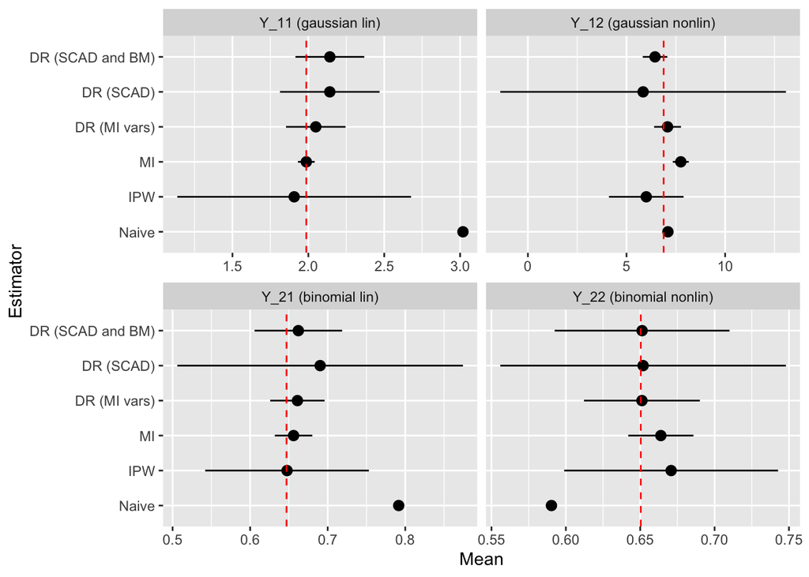

```r
ggplot(data = results, aes(x = estim, y = mean, ymin = lower_bound, ymax = upper_bound)) +
  geom_point() +
  geom_pointrange() +
  geom_hline(aes(yintercept = true), color = "red", linetype = "dashed") +
  facet_wrap(~y, scales = "free_x", labeller = labeller(y = c("Y_11" = "Y_11 (gaussian lin)",
                                                              "Y_12" = "Y_12 (gaussian nonlin)",
                                                              "Y_21" = "Y_21 (binomial lin)",
                                                              "Y_22" = "Y_22 (binomial nonlin)"))) +
  coord_flip() +
  labs(y = "Mean", x = "Estimator")
```

### 1.3.3 Estimators under PSM II

Naive estimator.

```r
est_naive <- aggregate(cbind(Y_11,Y_12,Y_21,Y_22) ~ 1, sample_B2, mean)
```

IPW with variable selection using SCAD penalty (note that this IPW is IPW with calibration constraints on selected variables).

```r
est_ipw <- nonprob(selection = X_formula,
                   target = ~ Y_11 + Y_12 + Y_21 + Y_22,
                   data = sample_B2,
                   svydesign = sample_A_svy_cal,
                   control_inference = controlInf(vars_selection = TRUE))
```

Mass imputation with SCAD penalty.

```r
est_mi_y11 <- nonprob(outcome = as.formula(paste("Y_11 ~ ", as.character(X_formula)[2])),
                      data = sample_B2,
                      svydesign = sample_A_svy_cal,
                      control_inference = controlInf(vars_selection = TRUE),
                      family_outcome = "gaussian")
est_mi_y12 <- nonprob(outcome = as.formula(paste("Y_12 ~ ", as.character(X_formula)[2])),
                      data = sample_B2,
                      svydesign = sample_A_svy_cal,
                      control_inference = controlInf(vars_selection = TRUE),
                      family_outcome = "gaussian")
est_mi_y21 <- nonprob(outcome = as.formula(paste("Y_21 ~ ", as.character(X_formula)[2])),
                      data = sample_B2,
                      svydesign = sample_A_svy_cal,
                      control_inference = controlInf(vars_selection = TRUE),
                      family_outcome = "binomial")
est_mi_y22 <- nonprob(outcome = as.formula(paste("Y_22 ~ ", as.character(X_formula)[2])),
                      data = sample_B2,
                      svydesign = sample_A_svy_cal,
                      control_inference = controlInf(vars_selection = TRUE),
                      family_outcome = "binomial")
```

DR with variables based on mass imputation with SCAD penalty.

```r
est_dr_pred_y11 <- nonprob(outcome = as.formula(paste("Y_11 ~ ",
                                                      paste(names(est_mi_y11$parameters[,1])[-1],
                                                            collapse = "+"))),
                           selection = as.formula(paste(" ~ ",
                                                      paste(names(est_mi_y11$parameters[,1])[-1],
                                                            collapse = "+"))),
                           data = sample_B2,
                           svydesign = sample_A_svy,
                           family_outcome = "gaussian")
est_dr_pred_y12 <- nonprob(outcome = as.formula(paste("Y_12 ~ ",
                                                      paste(names(est_mi_y12$parameters[,1])[-1],
                                                            collapse = "+"))),
                           selection = as.formula(paste(" ~ ",
                                                      paste(names(est_mi_y12$parameters[,1])[-1],
                                                            collapse = "+"))),
                           data = sample_B2,
                           svydesign = sample_A_svy,
                           family_outcome = "gaussian")
est_dr_pred_y21 <- nonprob(outcome = as.formula(paste("Y_21 ~ ",
                                                      paste(names(est_mi_y21$parameters[,1])[-1],
                                                            collapse = "+"))),
                           selection = as.formula(paste(" ~ ",
                                                      paste(names(est_mi_y21$parameters[,1])[-1],
                                                            collapse = "+"))),
                           data = sample_B2,
                           svydesign = sample_A_svy,
                           family_outcome = "binomial")

est_dr_pred_y22 <- nonprob(outcome = as.formula(paste("Y_22 ~ ",
                                                      paste(names(est_mi_y22$parameters[,1])[-1],
                                                            collapse = "+"))),
                           selection = as.formula(paste(" ~ ",
                                                      paste(names(est_mi_y22$parameters[,1])[-1],
                                                            collapse = "+"))),
                           data = sample_B2,
                           svydesign = sample_A_svy,
                           family_outcome = "binomial")
```

DR without bias minimization but with union of variables.

```r
est_dr_y11 <- nonprob(outcome = as.formula(paste("Y_11 ~ ", as.character(X_formula)[2])),
                     selection = X_formula,
                     data = sample_B2,
                     svydesign = sample_A_svy,
                     control_inference = controlInf(vars_selection = TRUE),
                     family_outcome = "gaussian")

est_dr_y12 <- nonprob(outcome = as.formula(paste("Y_12 ~ ", as.character(X_formula)[2])),
                     selection = X_formula,
                     data = sample_B2,
                     svydesign = sample_A_svy,
                     control_inference = controlInf(vars_selection = TRUE),
                     family_outcome = "gaussian")

est_dr_y21 <- nonprob(outcome = as.formula(paste("Y_21 ~ ", as.character(X_formula)[2])),
                     selection = X_formula,
                     data = sample_B2,
                     svydesign = sample_A_svy,
                     control_inference = controlInf(vars_selection = TRUE),
                     family_outcome = "binomial")

est_dr_y22 <- nonprob(outcome = as.formula(paste("Y_22 ~ ", as.character(X_formula)[2])),
                     selection = X_formula,
                     data = sample_B2,
                     svydesign = sample_A_svy,
                     control_inference = controlInf(vars_selection = TRUE),
                     family_outcome = "binomial")
```

DR with bias minimization with union of variables after selection of variables with SCAD.

```r
est_dr_mm_y11 <- nonprob(outcome = as.formula(paste("Y_11 ~ ", paste(rownames(est_dr_y11$parameters)[-1], collapse = "+"))),
                         selection = as.formula(paste(" ~ ", paste(rownames(est_dr_y11$parameters)[-1], collapse = "+"))),
                         data = sample_B2,
                         svydesign = sample_A_svy,
                         control_selection = controlSel(est_method_sel = "mm"),
                         family_outcome = "gaussian")
est_dr_mm_y12 <- nonprob(outcome = as.formula(paste("Y_12 ~ ", paste(rownames(est_dr_y12$parameters)[-1], collapse = "+"))),
                         selection = as.formula(paste(" ~ ", paste(rownames(est_dr_y12$parameters)[-1], collapse = "+"))),
                         data = sample_B2,
                         svydesign = sample_A_svy,
                         control_selection = controlSel(est_method_sel = "mm"),
                         family_outcome = "gaussian")
est_dr_mm_y21 <- nonprob(outcome = as.formula(paste("Y_21 ~ ", paste(rownames(est_dr_y21$parameters)[-1], collapse = "+"))),
                         selection = as.formula(paste(" ~ ", paste(rownames(est_dr_y21$parameters)[-1], collapse = "+"))),
                         data = sample_B2,
                         svydesign = sample_A_svy,
                         control_selection = controlSel(est_method_sel = "mm"),
                         family_outcome = "binomial")
est_dr_mm_y22 <- nonprob(outcome = as.formula(paste("Y_22 ~ ", paste(rownames(est_dr_y22$parameters)[-1], collapse = "+"))),
                         selection = as.formula(paste(" ~ ", paste(rownames(est_dr_y22$parameters)[-1], collapse = "+"))),
                         data = sample_B2,
                         svydesign = sample_A_svy,
                         control_selection = controlSel(est_method_sel = "mm"),
                         family_outcome = "binomial")
```

Compare results

```r
results <- rbind(
  cbind(est_ipw$output,est_ipw$confidence_interval),
  cbind(est_mi_y11$output,est_mi_y11$confidence_interval),
  cbind(est_mi_y12$output,est_mi_y12$confidence_interval),
  cbind(est_mi_y21$output,est_mi_y21$confidence_interval),
  cbind(est_mi_y22$output,est_mi_y22$confidence_interval),
  cbind(est_dr_pred_y11$output,est_dr_pred_y11$confidence_interval),
  cbind(est_dr_pred_y12$output,est_dr_pred_y12$confidence_interval),
  cbind(est_dr_pred_y21$output,est_dr_pred_y21$confidence_interval),
  cbind(est_dr_pred_y22$output,est_dr_pred_y22$confidence_interval),
  #cbind(est_dr_y11$output,est_dr_y11$confidence_interval),
  #cbind(est_dr_y12$output,est_dr_y12$confidence_interval),
  #cbind(est_dr_y21$output,est_dr_y21$confidence_interval),
  #cbind(est_dr_y22$output,est_dr_y22$confidence_interval),
  #cbind(est_dr_mm_y11$output,est_dr_mm_y11$confidence_interval),
  #cbind(est_dr_mm_y12$output,est_dr_mm_y12$confidence_interval),
  #cbind(est_dr_mm_y21$output,est_dr_mm_y21$confidence_interval),
  #cbind(est_dr_mm_y22$output,est_dr_mm_y22$confidence_interval),
  data.frame(mean = t(est_naive), SE = NA, lower_bound = NA, upper_bound = NA)
)
rownames(results) <- NULL
results$y <- rep(c("Y_11", "Y_12", "Y_21", "Y_22"), rep = 4)
results$estim <- rep(c("IPW", "MI", "DR (MI vars)",
                       #"DR (SCAD)", "DR (SCAD and BM)",
                       "Naive"), each = 4)
results$estim <- factor(results$estim, c("Naive", "IPW", "MI", "DR (MI vars)"
                                         #,"DR (SCAD)", "DR (SCAD and BM)"
                                         ))
results$true  <- rep(c(mean(Y_11), mean(Y_12), mean(Y_21), mean(Y_22)), rep = 6)
results <- results[, c("y", "estim", "mean", "SE", "lower_bound", "upper_bound", "true")]
results <- results[order(results$y, results$estim),]
```

|  | y | estim | mean | SE | lower_bound | upper_bound | true |
| --- | --- | --- | --- | --- | --- | --- | --- |
| 13 | Y_11 | Naive | 1.7912136 | NA | NA | NA | 1.986659 |
| 1 | Y_11 | IPW | 1.9520180 | 0.1997278 | 1.5605588 | 2.3434773 | 1.986659 |
| 5 | Y_11 | MI | 1.9568190 | 0.0231757 | 1.9113954 | 2.0022426 | 1.986659 |
| 9 | Y_11 | DR (MI vars) | 2.0076324 | 0.1032904 | 1.8051870 | 2.2100777 | 1.986659 |
| 14 | Y_12 | Naive | 5.6450654 | NA | NA | NA | 6.883215 |
| 2 | Y_12 | IPW | 5.6471917 | 0.2311590 | 5.1941284 | 6.1002549 | 6.883215 |
| 6 | Y_12 | MI | 5.6332705 | 0.1489424 | 5.3413487 | 5.9251923 | 6.883215 |
| 10 | Y_12 | DR (MI vars) | 5.7154861 | 0.1681607 | 5.3858972 | 6.0450750 | 6.883215 |
| 15 | Y_21 | Naive | 0.5848469 | NA | NA | NA | 0.646900 |
| 3 | Y_21 | IPW | 0.6069811 | 0.0262930 | 0.5554478 | 0.6585143 | 0.646900 |
| 7 | Y_21 | MI | 0.6388783 | 0.0109201 | 0.6174754 | 0.6602813 | 0.646900 |
| 11 | Y_21 | DR (MI vars) | 0.6453256 | 0.0163907 | 0.6132005 | 0.6774508 | 0.646900 |
| 16 | Y_22 | Naive | 0.6294759 | NA | NA | NA | 0.650400 |
| 4 | Y_22 | IPW | 0.5050797 | 0.0309040 | 0.4445089 | 0.5656505 | 0.650400 |
| 8 | Y_22 | MI | 0.5626135 | 0.0115108 | 0.5400528 | 0.5851742 | 0.650400 |
| 12 | Y_22 | DR (MI vars) | 0.5487953 | 0.0183425 | 0.5128446 | 0.5847460 | 0.650400 |

Plot results from one go

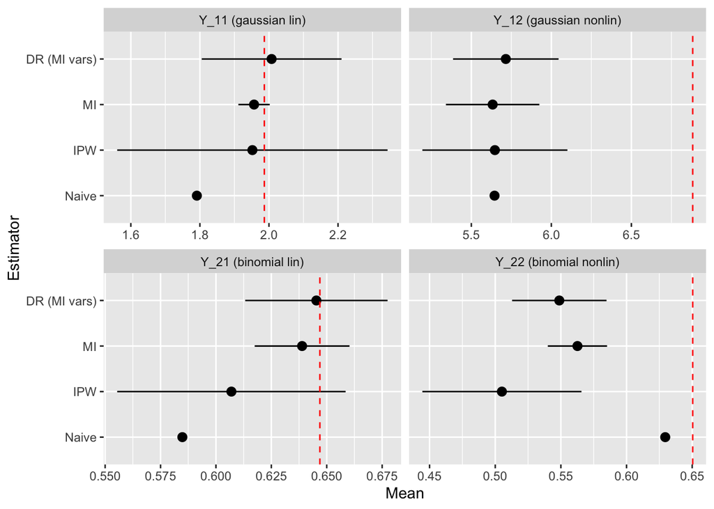

```r
ggplot(data = results, aes(x = estim, y = mean, ymin = lower_bound, ymax = upper_bound)) +
  geom_point() +
  geom_pointrange() +
  geom_hline(aes(yintercept = true), color = "red", linetype = "dashed") +
  facet_wrap(~y, scales = "free_x", labeller = labeller(y = c("Y_11" = "Y_11 (gaussian lin)",
                                                              "Y_12" = "Y_12 (gaussian nonlin)",
                                                              "Y_21" = "Y_21 (binomial lin)",
                                                              "Y_22" = "Y_22 (binomial nonlin)"))) +
  coord_flip() +
  labs(y = "Mean", x = "Estimator")
```